# Haunt KO vs WT (Adult)

This file shows the wt-v-ko comparison for Haunt.

Cuff overview:

```
## CuffSet instance with:
##   2 samples
##   26754 genes
##   77524 isoforms
##   0 TSS
##   23066 CDS
##   0 promoters
##   0 splicing
##   19954 relCDS
```

# QC

## Dispersion

Dispersion plot for genes in cuff: (Overdispersion can lead to innacurate quants)

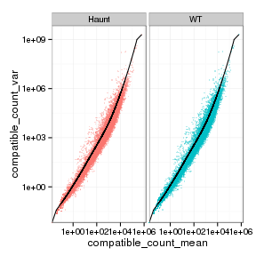

## Cross-replicate variability (fpkmSCVplot)

Differences in CV 2 can result in lower numbers of differentially expressed genes due to a higher degree of variability between replicate fpkm estimates.

Genes:

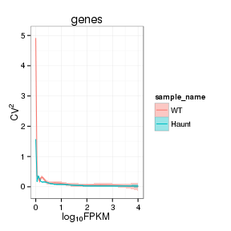

Isoforms:

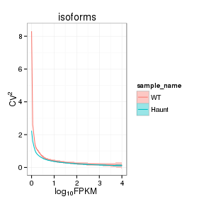

## MvA plot

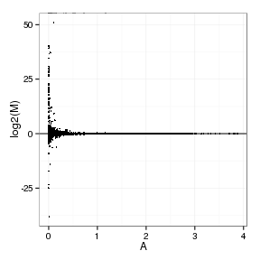

### MvA plot counts

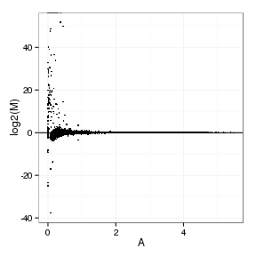

## Scatterplot matrix

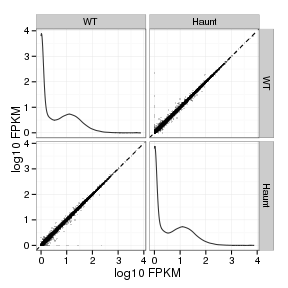

## Distributions

### Boxplots

Boxplot (genes)

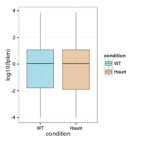

Boxplot (genes, replicates)

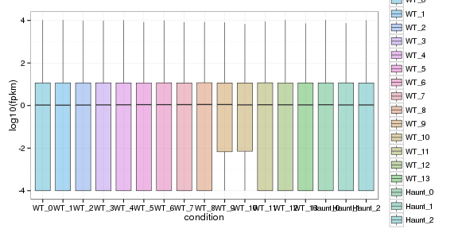

Boxplot (isoforms)

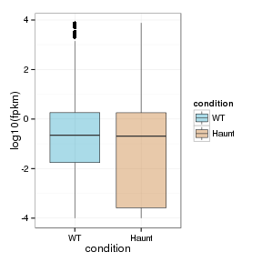

Boxplot (isoforms, replicates)

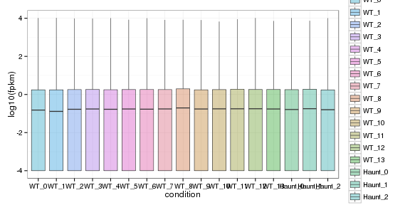

### Density

Density (genes)

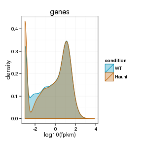

Density (genes, replicates)

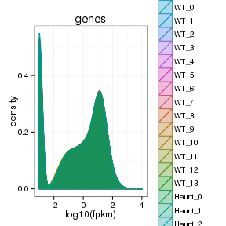

## Clustering

### Replicate Clusters

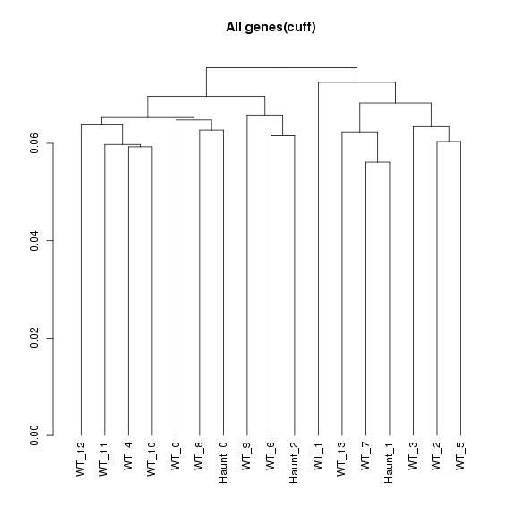

### PCA (genes)

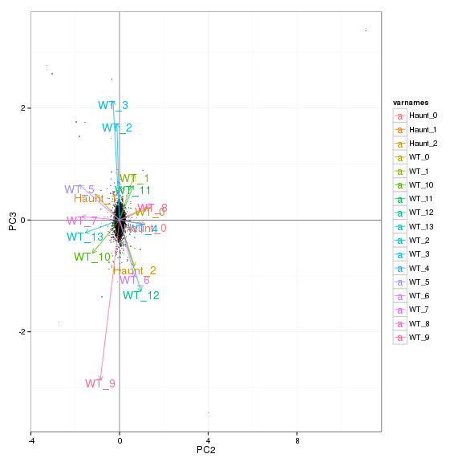

### MDS (genes)

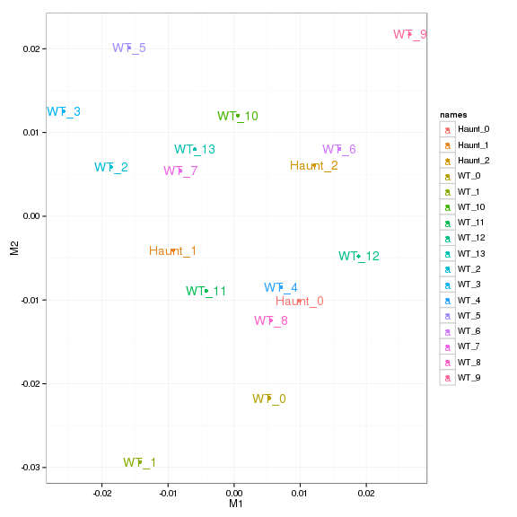

# KO assessment

## Endogenous lncRNA expression

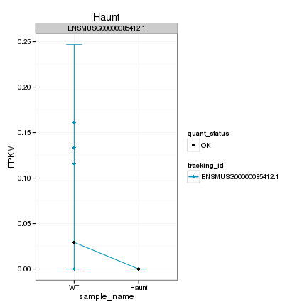

Endogenous expression of Haunt isoforms:

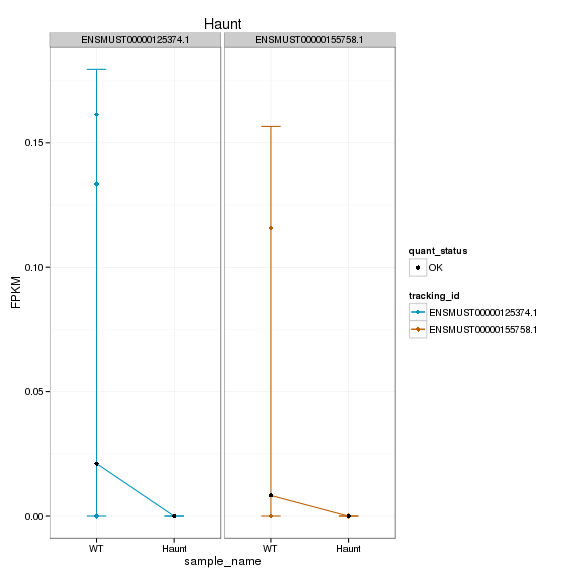

Barplot of gene expression:

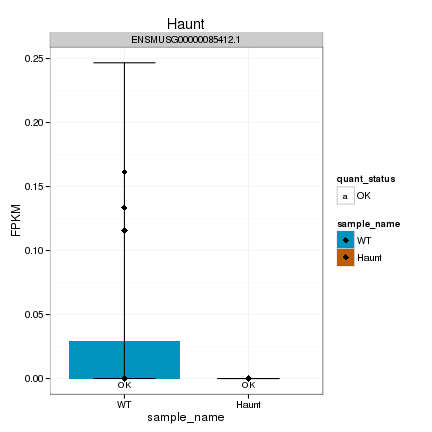

Barplot of isoform expression:

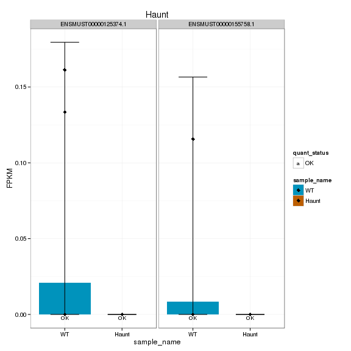

## LacZ expression

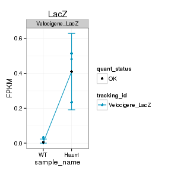

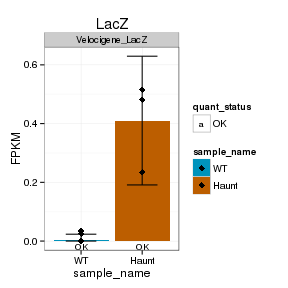

## Digital Genotyping (LacZ vs Endogenous lncRNA and Sex)

Eif2s3y is a y-expressed gene, Xist is an x-expressed gene Expression plot (endogenous linc, lacZ, Y-expressed gene):

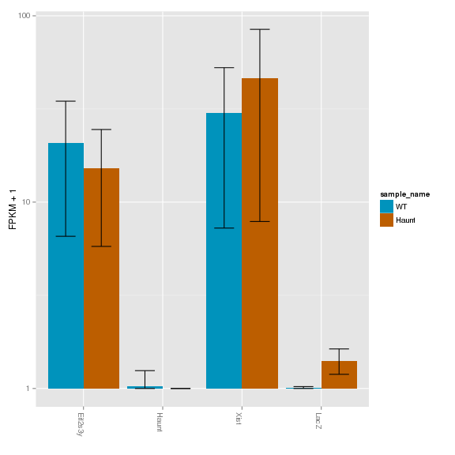

Expression heatmap:

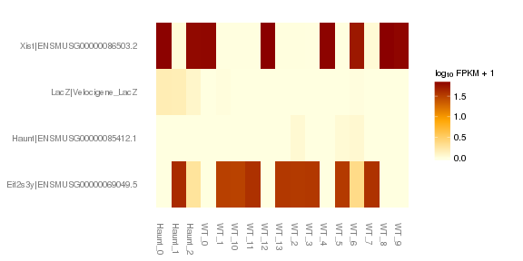

### Track visualization

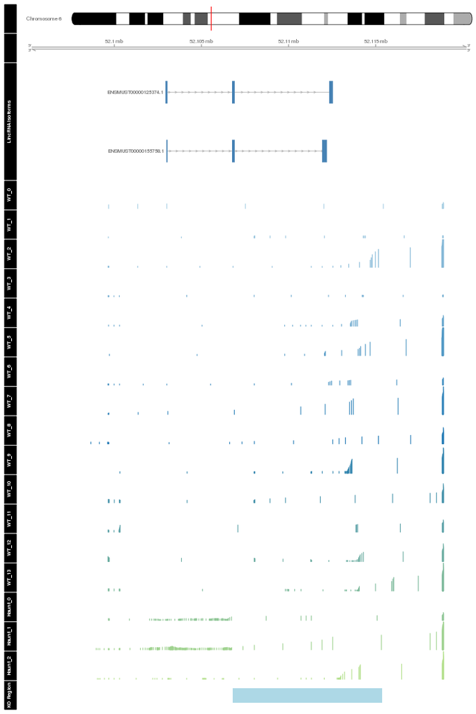

# Differential Analysis

## Differential Genes

There are 37 significantly differentially expressed genes. They are:

|  | geneAnnot$gene_short_name |
| --- | --- |
| 1 | Hspa8 |
| 2 | Ubb |
| 3 | Dusp6 |
| 4 | Pttg1 |
| 5 | Adi1 |
| 6 | Serpina3n |
| 7 | Fos |
| 8 | Arc |
| 9 | Nr4a1 |
| 10 | Glo1 |
| 11 | Xdh |
| 12 | Nr4a3 |
| 13 | Hddc3 |
| 14 | Cryab |
| 15 | Arhgap27 |
| 16 | Fam214a |
| 17 | Filip1 |
| 18 | Klf10 |
| 19 | Egr2 |
| 20 | Txnip |
| 21 | Egr1 |
| 22 | Akap12 |
| 23 | Atp5l |
| 24 | Maff |
| 25 | Gm9493 |
| 26 | Acp1 |
| 27 | Npas4 |
| 28 | Hbb-bs |
| 29 | Junb |
| 30 | Kdm5d |
| 31 | Tpm3-rs7 |
| 32 | Rpl34 |
| 33 | Ddx3y |
| 34 | Egr4 |
| 35 | Gm7292 |
| 36 | AA465934 |
| 37 | Gm26825 |

### Matrix of gene significant differences between conditions

(skip for Brainmap wt-v-ko comparisons)

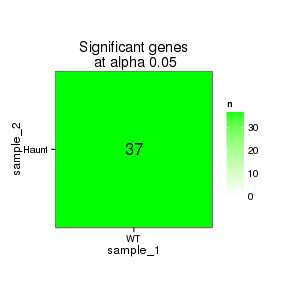

### Significant gene expression differences between conditions

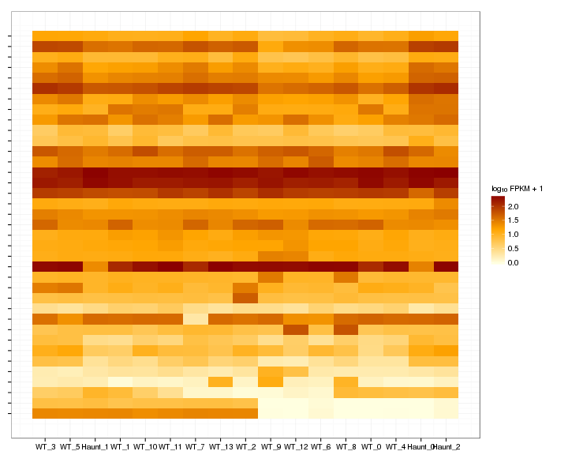

Significant genes with expression >50fpkm (any condition):(turned off)

An individual look at each of the highly expressed significantly differentially regulated genes: (eval=false for first pass)

### Expression-level/significance relationship

Scatter plot of significant genes only:

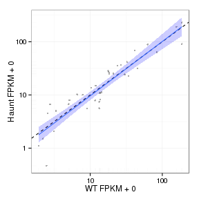

Volcano Plot

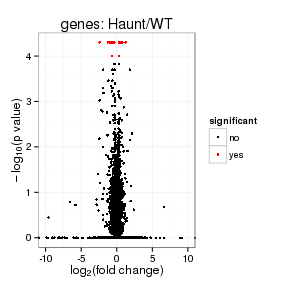

Volcano plot with significant genes only:

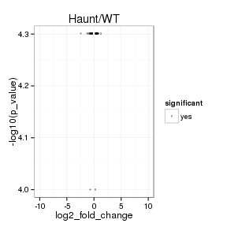

FoldChange Heatmap

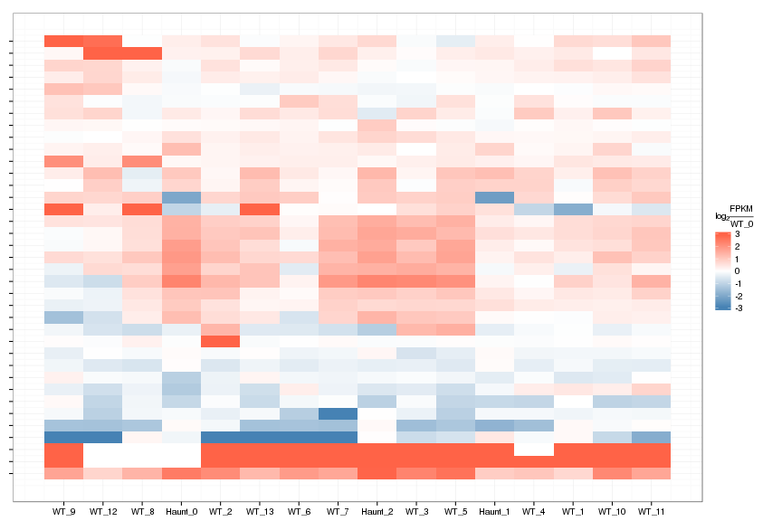

## Differential Splicing

### Differential Isoforms between conditions

Per isoform difference between conditions:

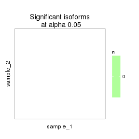

These isoforms are:

[1] “no sig isoforms”

Gene-level DE isoform heatmap

```
## [1] "no sig isoforms"
```

Isoform foldchange heatmap by isoform:

```
## [1] "no sig isoforms"
```

### Differential Splicing between conditions

(eval false for first pass)

Per condition differences in isoforms (Does gene have diff piechart between conditions?)

Splicing heatmap by isoform:

Splicing heatmap by gene

# Gene/Pathway Analysis

## GSEA

Enrichment and zscores are calculated based on expression in KO vs WT (fpkmKO/fpkmWT), so genes that are down regulated in KO are shown in blue, while upregulation is shown in red.

KO/WT Blue = down in KO Red = Up in KO

Biocarta enrichment:

[output not shown]

Biocarta zscore:

[output not shown]

[output not shown]

[output not shown]

[output not shown]

Reactome enrichment:

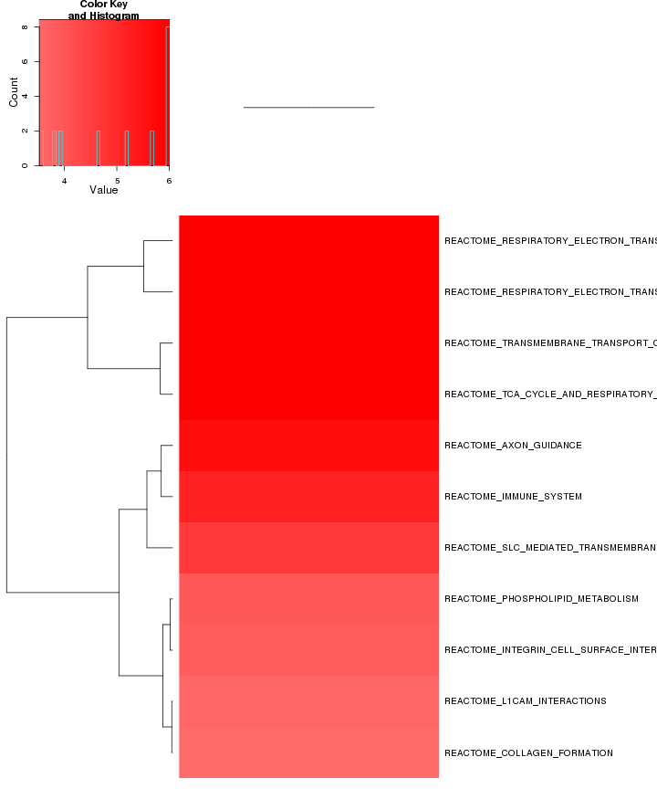

Reactome zscore:

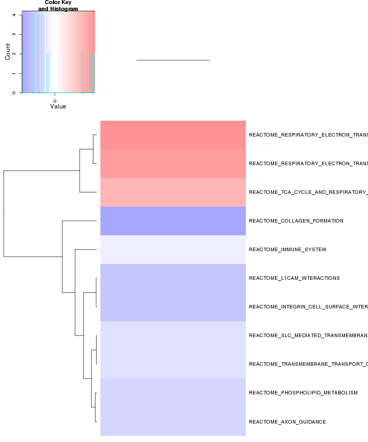

Kegg enrichment:

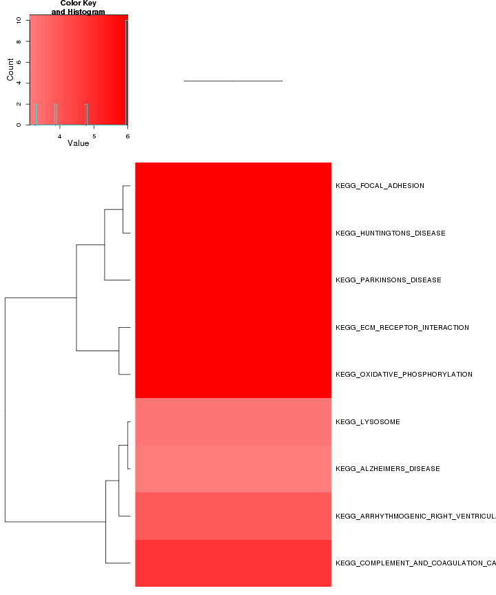

Kegg zscore:

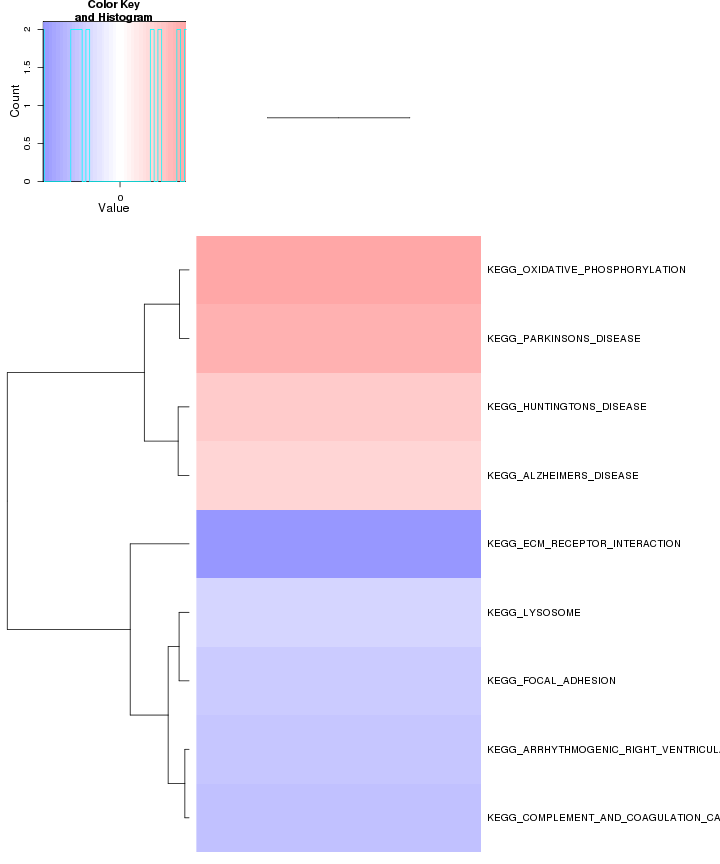

Interneuron enrichment:

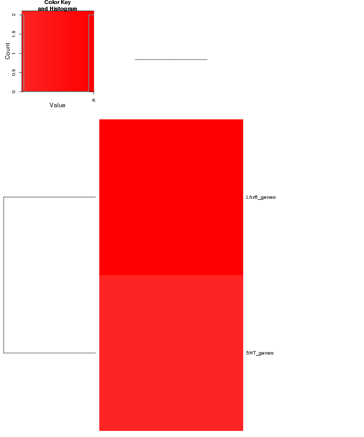

Interneuron zscore:

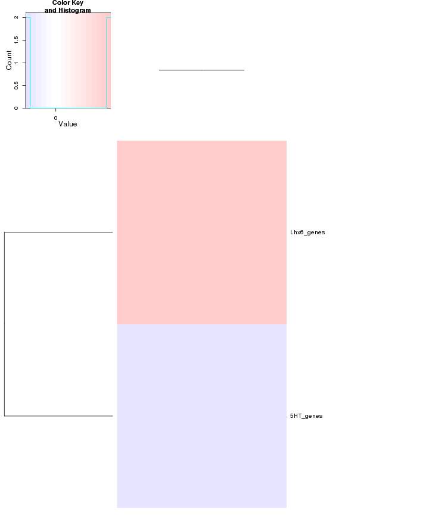

Oncogene enrichment:

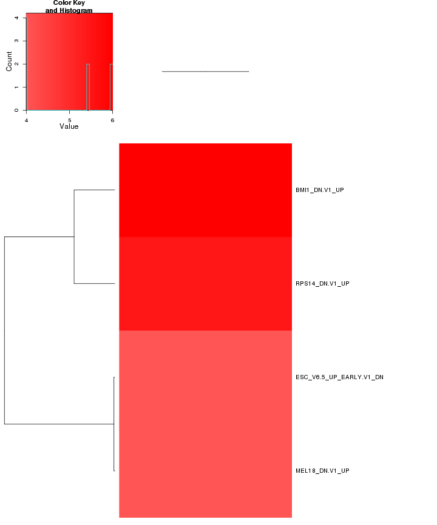

Oncogene zscore:

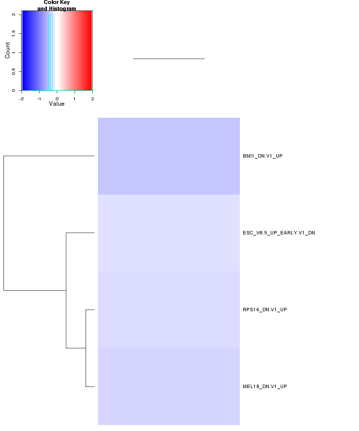

Immuno enrichment:

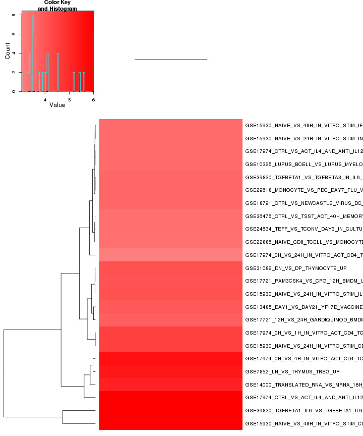

Immuno zscore:

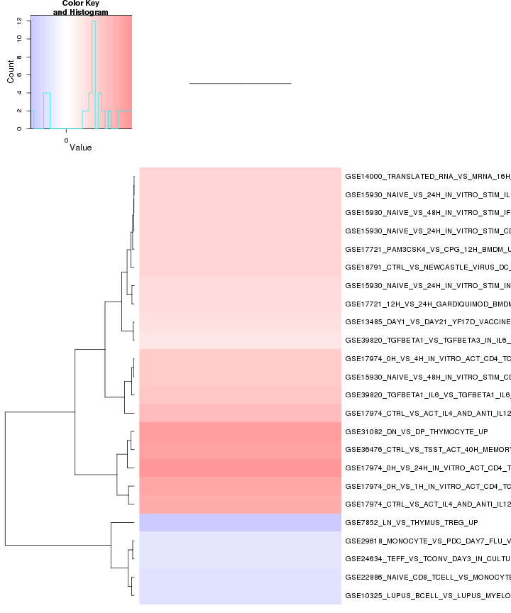

TF enrichment:

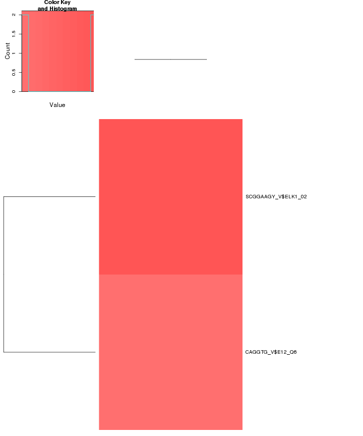

TF zscore:

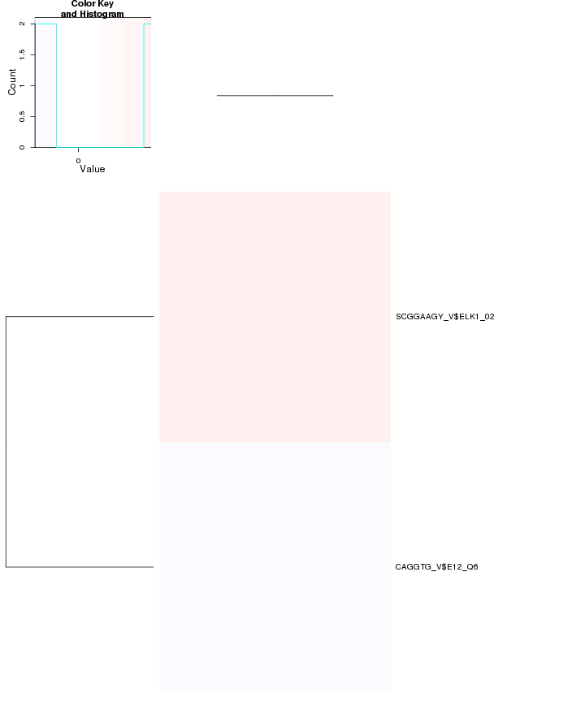

## GO enrichment

Cluster profiler used to call enichments of significantly differentially regulated genes that map to Entrez IDs.

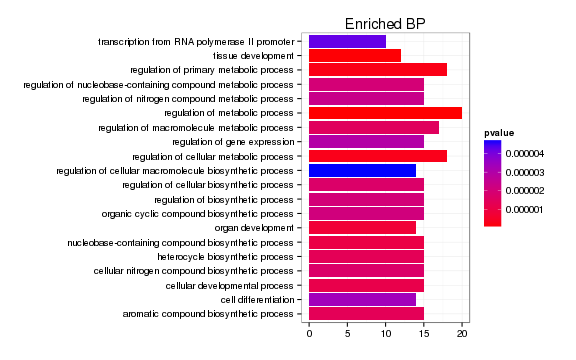

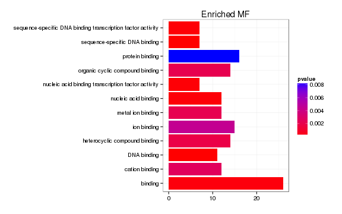

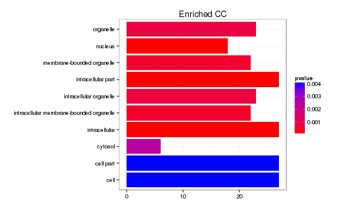

[output not shown]

[output not shown]

### Enrichment or depletion for stage-specific cell cycle markers

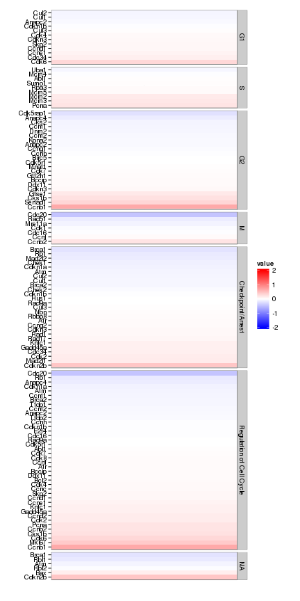

### Enrichment or depletion for markers of specific cortical layers

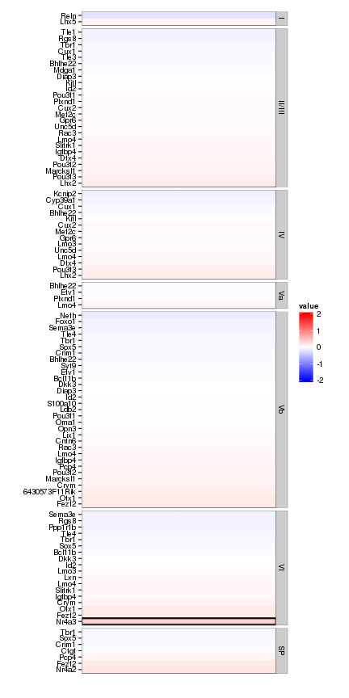

### Enrichment or depletion for specific neural cell types

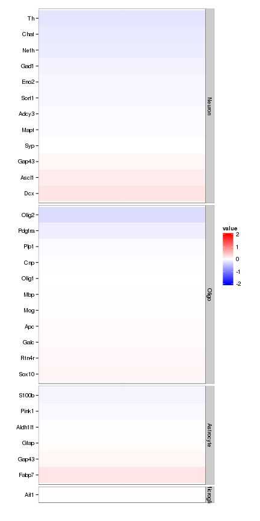

### Enrichment or Depletion of neural differentiation markers

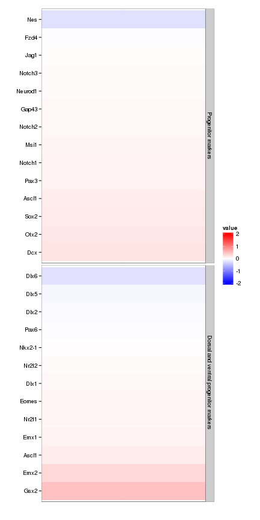

# Cis vs Trans (locally)

log2 Foldchange and test statistic are calculated with the ratio of fpkm(KO)/fpkm(WT), thus the test_stat is positive if a gene is higher in the KO and negative if a gene has lower expression in the KO

The pvalue for 0 genes significantly regulated in a region this size is: 1

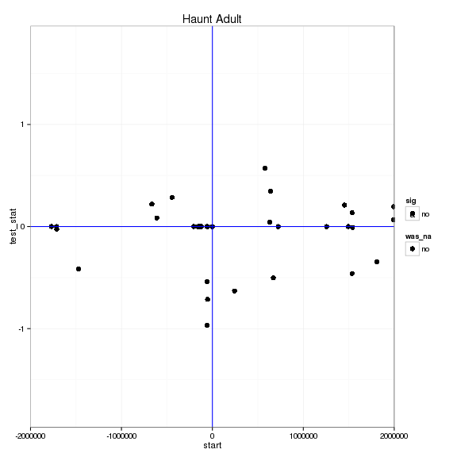

# Notes

## Samples used are:

|  | 10 |
| --- | --- |
| 1 | JR729 |
| 2 | JR728 |
| 3 | JR796 |
| 4 | JR797 |
| 5 | JR740 |
| 6 | JR800 |
| 7 | JR827 |
| 8 | JR778 |
| 9 | JR734 |
| 10 | JR802 |
| 11 | JR803 |
| 12 | JR735 |
| 13 | JR785 |
| 14 | JR781 |
| 15 | JR738 |
| 16 | JR782 |
| 17 | JR826 |

## Replicates

|  | file | sample_name | replicate | rep_name | total_mass | norm_mass | internal_scale | external_scale |
| --- | --- | --- | --- | --- | --- | --- | --- | --- |
| 1 | /n/rinn_data1/seq/lgoff/Projects/BrainMap/data/quants/JR729/abundances.cxb | WT | 0 | WT_0 | 26334400.00 | 34083500.00 | 0.77 | 1.00 |
| 2 | /n/rinn_data1/seq/lgoff/Projects/BrainMap/data/quants/JR728/abundances.cxb | WT | 1 | WT_1 | 20329200.00 | 34083500.00 | 0.59 | 1.00 |
| 3 | /n/rinn_data1/seq/lgoff/Projects/BrainMap/data/quants/JR796/abundances.cxb | WT | 2 | WT_2 | 34089000.00 | 34083500.00 | 1.00 | 1.00 |
| 4 | /n/rinn_data1/seq/lgoff/Projects/BrainMap/data/quants/JR797/abundances.cxb | WT | 3 | WT_3 | 28103300.00 | 34083500.00 | 0.81 | 1.00 |
| 5 | /n/rinn_data1/seq/lgoff/Projects/BrainMap/data/quants/JR740/abundances.cxb | WT | 4 | WT_4 | 35808200.00 | 34083500.00 | 1.05 | 1.00 |
| 6 | /n/rinn_data1/seq/lgoff/Projects/BrainMap/data/quants/JR800/abundances.cxb | WT | 5 | WT_5 | 37012200.00 | 34083500.00 | 1.09 | 1.00 |
| 7 | /n/rinn_data1/seq/lgoff/Projects/BrainMap/data/quants/JR827/abundances.cxb | WT | 6 | WT_6 | 27786600.00 | 34083500.00 | 0.82 | 1.00 |
| 8 | /n/rinn_data1/seq/lgoff/Projects/BrainMap/data/quants/JR778/abundances.cxb | WT | 7 | WT_7 | 39541900.00 | 34083500.00 | 1.17 | 1.00 |
| 9 | /n/rinn_data1/seq/lgoff/Projects/BrainMap/data/quants/JR734/abundances.cxb | WT | 8 | WT_8 | 34480600.00 | 34083500.00 | 1.03 | 1.00 |
| 10 | /n/rinn_data1/seq/lgoff/Projects/BrainMap/data/quants/JR802/abundances.cxb | WT | 9 | WT_9 | 45467400.00 | 34083500.00 | 1.32 | 1.00 |
| 11 | /n/rinn_data1/seq/lgoff/Projects/BrainMap/data/quants/JR803/abundances.cxb | WT | 10 | WT_10 | 52130400.00 | 34083500.00 | 1.53 | 1.00 |
| 12 | /n/rinn_data1/seq/lgoff/Projects/BrainMap/data/quants/JR735/abundances.cxb | WT | 11 | WT_11 | 34994400.00 | 34083500.00 | 1.03 | 1.00 |
| 13 | /n/rinn_data1/seq/lgoff/Projects/BrainMap/data/quants/JR785/abundances.cxb | WT | 12 | WT_12 | 34173600.00 | 34083500.00 | 0.99 | 1.00 |
| 14 | /n/rinn_data1/seq/lgoff/Projects/BrainMap/data/quants/JR781/abundances.cxb | WT | 13 | WT_13 | 41538900.00 | 34083500.00 | 1.22 | 1.00 |
| 15 | /n/rinn_data1/seq/lgoff/Projects/BrainMap/data/quants/JR738/abundances.cxb | Haunt | 0 | Haunt_0 | 26084100.00 | 34083500.00 | 0.77 | 1.00 |
| 16 | /n/rinn_data1/seq/lgoff/Projects/BrainMap/data/quants/JR782/abundances.cxb | Haunt | 1 | Haunt_1 | 43523200.00 | 34083500.00 | 1.28 | 1.00 |
| 17 | /n/rinn_data1/seq/lgoff/Projects/BrainMap/data/quants/JR826/abundances.cxb | Haunt | 2 | Haunt_2 | 33775800.00 | 34083500.00 | 0.99 | 1.00 |

## Run Info

[output not shown]